# Modelowanie tematyczne i analiza sentymentu pojazdów elektrycznych na podstawie danych z Reddit

Aleksandra Załęska

Styczeń, 2024

# Instalacja bibliotek

Niezbędne biblioteki:

```python
import pandas as pd
import matplotlib.pyplot as plt
import seaborn as sns
import json
import os
import re
import nltk
import spacy

from nltk.sentiment import SentimentIntensityAnalyzer
from nltk.corpus import stopwords
from nltk.stem import WordNetLemmatizer
from nltk.tokenize import word_tokenize, sent_tokenize
from nltk import pos_tag
from sklearn.feature_extraction.text import TfidfVectorizer
from sklearn.decomposition import LatentDirichletAllocation
from wordcloud import WordCloud

nltk.download('stopwords')
nltk.download('wordnet')
nltk.download('omw-1.4')
nltk.download('punkt')
nltk.download('averaged_perceptron_tagger')
nltk.download('vader_lexicon')
```

```
True
```

# Zebranie danych

Dane wykorzystane w tym projekcie pochodzą ze strony: https://the-eye.eu/redarcs/. Wykorzystano dwa subreddity: r/Cars oraz r/cartalk i pobrano pliki dla postów oraz komentarzy.

Wczytanie plików JSON dla postów. Wczytywany plik jest jedynie plikiem przykładowym i nie stanowi całości pliku, który został wykorzystany w dalszej analizie. Służy przedstawieniu działania poniższych funkcji:

Funkcja wczytująca pliki JSON:

```python
def load_json_file(file_path):
    with open(file_path, 'r', encoding='utf-8') as file:
        data = [json.loads(line) for line in file]
    return data
```

Podanie ścieżki do pliku JSON:

```python
input_file_path = r'C:\Users\sciezka_do_pliku'
```

Załadowanie pliku JSON:

```python
cartalk_submissions = load_json_file(input_file_path)
```

Wyświetlenie dwóch pierwszych elementów:

```python
for i, element in enumerate(cartalk_submissions[:2], 1):
    print(f"Element {i}: {element}")
```

```
Element 1: {'archived': True, 'author': 'darthcaldwell', 'author_flair_background_color': None, 'author_flair_css_class': '', 'author_flair_richtext': [{'e': 'text', 't': 'Michael Bolton'}], 'author_flair_text': 'Michael Bolton', 'author_flair_text_color': None, 'author_flair_type': 'richtext', 'bra…
Element 2: {'archived': True, 'author': 'darthcaldwell', 'author_flair_background_color': None, 'author_flair_css_class': '', 'author_flair_richtext': [{'e': 'text', 't': 'Michael Bolton'}], 'author_flair_text': 'Michael Bolton', 'author_flair_text_color': None, 'author_flair_type': 'richtext', 'bra…
```

Odfiltrowanie określonych kluczy, które bedą dla nas przydatne:

Funkcja do odlflitrowania:

```python
def filter_json(json_data, keys):
    filtered_data = []
    for item in json_data:
        filtered_item = {key: item[key] for key in keys if key in item}
        filtered_data.append(filtered_item)
    return filtered_data
```

Wybrane klucze:

```python
selected_keys = ["author", "score", "selftext", "subreddit", "created_utc", "name", "url", "num_comments"]
```

Filtrowanie danych korzystając z funkcji:

```python
cartalk_submissions_filtered = filter_json(cartalk_submissions, selected_keys)
```

Wyświetlenie dwóch pierwszych elementów:

```python
for i, element in enumerate(cartalk_submissions_filtered[:2], 1):
    print(f"Element {i}: {element}")
```

```
Element 1: {'author': 'darthcaldwell', 'score': 3, 'selftext': '', 'subreddit': 'Cartalk', 'created_utc': 1284958054, 'url': 'http://www.reddit.com/r/AskReddit/comments/dg4ae/in_the_spirit_of_helping_out_i_reach_out_to_my/', 'num_comments': 0}
Element 2: {'author': 'darthcaldwell', 'score': 6, 'selftext': "I am offering my services with basic mechanical automotive needs in the Madison WI area. I am (unfortunately) unable to pay for parts, but I will give free labor! Let me know what you need done, and I will try to make it happen! If you'…
```

Przekształcenie danych na DataFrame:

```python
cartalk_submissions_df = pd.DataFrame(cartalk_submissions_filtered)
```

Usunięcie wierszy, które w kolumnie 'name' mają wartość 'NaN', ponieważ w kolumnie tej znajdują się unikalne wartości stanowiące później kolumnę łączącą posty z komentarzami:

```python
cartalk_submissions_df.dropna(subset=['name'], inplace=True)
```

Odfiltrowanie wierszy, które w kolumnie 'selftext', czyli w kolumnie, która przechowuje treść postów występują frazy takie jak: "electric car", "electric cars", "electric vehicle", "electric vehicles", "evs". W tym celu na kolumnie 'selftext' należy przeprowadzić kilka operacji:

Usunięcie znaków interpunkcyjnych, wykrzyknień, pytajników itp.:

```python
cartalk_submissions_df['selftext'] = cartalk_submissions_df['selftext'].str.replace(r'[^\w\s]', '', regex=True)
```

Usunięcie znaków nowej linii:

```python
cartalk_submissions_df['selftext'] = cartalk_submissions_df['selftext'].str.replace('\n', ' ')
```

Zamiana wszystkich liter na małe:

```python
cartalk_submissions_df['selftext'] = cartalk_submissions_df['selftext'].str.lower()
```

Lista słów kluczowych:

```python
keywords = ["electric car", "electric cars", "electric vehicle", "electric vehicles", "evs"]
```

Warunek logiczny sprawdzający, czy któryś z kluczowych słów występuje w kolumnie 'selftext'/:

```python
condition = cartalk_submissions_df['selftext'].str.contains('|'.join(keywords), case=False)
```

Wybieranie wierszy spełniających warunek:

```python
cartalk_submissions_df_with_keywords = cartalk_submissions_df[condition]
```

Zapisanie DataFrame do pliku Excel:

```python
cartalk_submissions_df_with_keywords.to_excel('cartalk_posts.xlsx', index=False)
```

Wczytanie plików JSON dla komentarzy:

Korzystamy z wczesniej stworzonej funckji load_json_file:

Podanie ścieżki do pliku:

```python
input_file_path_2 = r'C:\Users\sciezka_do_pliku'
```

Załadowanie pliku JSON z komentarzami:

```python
cartalk_comments = load_json_file(input_file_path_2)
```

Wyświetlenie dwóch pierwszych elementów:

```python
for i, element in enumerate(cartalk_comments[:2], 1):
    print(f"Element {i}: {element}")
```

```
Element 1: {'link_id': 't3_dg929', 'parent_id': 't3_dg929', 'retrieved_on': 1426477136, 'body': 'Home Cheapo and Lowes have some good cheap stuff. I Got a 30 something piece stainless steel Cobalt ratchet set at Lowes for under $40', 'author_flair_text': 'may be a red stapler', 'author_flair_css_cla…
Element 2: {'link_id': 't3_dgc01', 'parent_id': 't3_dgc01', 'retrieved_on': 1426477150, 'body': 'The worst thing about cambelts (timing belts) is that they could look brand new until they day they snap. Stress fractures could easily be hidden inside the belt. Change it at the required service interv…
```

Odfiltrowanie tylko kluczy: "author", "score", "body", "subreddit", "created_utc", "link_id". W tym celu wykorzystamy ponownie wczesniejszą funkcję filter_json:

```python
selected_keys = ["author", "score", "body", "subreddit", "created_utc", "link_id"]
```

```python
cartalk_comments_filtered = filter_json(cartalk_comments, selected_keys)
```

Wyświetlenie dwóch pierwszych elementów:

```python
for i, element in enumerate(cartalk_comments_filtered[:2], 1):
    print(f"Element {i}: {element}")
```

```
Element 1: {'author': 'terqui', 'score': 2, 'body': 'Home Cheapo and Lowes have some good cheap stuff. I Got a 30 something piece stainless steel Cobalt ratchet set at Lowes for under $40', 'subreddit': 'Cartalk', 'created_utc': '1284987638', 'link_id': 't3_dg929'}
Element 2: {'author': 'terqui', 'score': 2, 'body': 'The worst thing about cambelts (timing belts) is that they could look brand new until they day they snap. Stress fractures could easily be hidden inside the belt. Change it at the required service intervals. I mean you dont *have* to fix it. It co…
```

Przekształcenie na DataFrame:

```python
cartalk_comments = pd.DataFrame(cartalk_comments_filtered)
```

Odfiltrowanie ramki danych cars_comments, tak aby pozostawić tylko to wiersze, które w kolumnie 'link_id' posiadają wartośći, które występują także w kolumnie 'name' w tabeli cartalk_submissions_df_with_keywords:

```python
cartalk_comments = cartalk_comments[cartalk_comments['link_id'].isin(cartalk_submissions_df_with_keywords['name'])]
```

Zapisanie DataFrame do pliku Excel:

```python
cartalk_comments.to_excel('cartalk_comments.xlsx', index=False, encoding='utf-8')
```

# Przetwarzanie danych

Załadowanie tabel z plików Excel:

```python
cars_comm = pd.read_excel('https://docs.google.com/spreadsheets/d/e/2PACX-1vQbudhhu7rixkAetFc7Bj4Hgh-47mCiYv40dUYgccX8kwrlDWdGtc7yb3nTfu_MMQ/pub?output=xlsx')
cartalk_comm = pd.read_excel('https://docs.google.com/spreadsheets/d/e/2PACX-1vSWtTNocelTZ-89zGEzawpUeE0PnVitvEuWPRq2Z074wGRRx_2B0VHSBxD5yHyPoQ/pub?output=xlsx')
```

```python
cars_posts = pd.read_excel('https://docs.google.com/spreadsheets/d/e/2PACX-1vRNTTCM4HQOgHrZxCM-RlO2Uz-5VOkkwO4dEo6su4iSraUjRSL24hVrXq9nQIdUag/pub?output=xlsx')
cartalk_posts = pd.read_excel('https://docs.google.com/spreadsheets/d/e/2PACX-1vRT0BPUALq_swCALsinT9zMCQhpmQayYab2_SNDZUkE2_i8qZxUrQ9N24GbnWZLqQ/pub?output=xlsx')
```

Złączenie plików z danymi z komentarzy w jeden zbiór:

```python
ev_comments = pd.concat([cars_comm, cartalk_comm])
```

Złączenie plików z danymi z postów w jeden zbiór:

```python
ev_posts = pd.concat([cars_posts, cartalk_posts])
```

Przekształcenie formatu kolumny ev_posts['created_utc']:

```python
ev_posts['created_utc'] = pd.to_datetime(ev_posts['created_utc'], unit='s')
```

```python
ev_posts['created_utc'] = ev_posts['created_utc'].dt.strftime('%Y-%m-%d')
```

Filtrowanie postów od od 01-01-2012 do 31-12-2022:

```python
ev_posts = ev_posts[(ev_posts['created_utc'] >= '2012-01-01') & (ev_posts['created_utc'] <= '2022-12-31')]
```

Pobranie listy stop words z NLTK:

```python
stop_words = set(stopwords.words('english'))
```

Dodanie niestandardowych stop words

```python
custom_stop_words = set(['lol', 'itâs', 'iâm', 'donât', 'youre', 'iam', 'yes', 'guy', 'like', 'dont', 'doesnt',
                         'model', 'thats', 'yeah', 'le', 'adhd', 'ive', 'ill', 'even', 'one', 'though', 'think',
                         'thing', 'weve', 'kinda'])
stop_words.update(custom_stop_words)
```

Pobranie lematyzatora z NLTK:

```python
lemmatizer = WordNetLemmatizer()
```

Przed analizą sentymentu należy usunąć frazy: "electric car", "electric cars", "electric vehicle", "electric vehicles", "evs"

```python
phrases_to_remove = ["electric car", "electric cars", "electric vehicle", "electric vehicles",
                     "evs", "[deleted]", "car", "cars"]
```

Funkcja do przetworzenia danych:

```python
def preprocess_text(text, phrases_to_remove, remove_numbers=True):
    if pd.isna(text):
        return ''

    text = re.sub(r'[^\w\s]', '', text)
    text = text.lower()

    for phrase in phrases_to_remove:
        text = text.replace(phrase, '')

    if remove_numbers:
        text = re.sub(r'\d+', '', text)

    tokens = word_tokenize(text)

    # usuwanie słów krótszych niż 3 znaki
    tokens = [word for word in tokens if len(word) > 2]

    # usuwanie słów spoza angielskiego
    tokens = [word for word in tokens if word.isalpha()]

    # usuwanie stop words
    tokens = [word for word in tokens if word not in stop_words]

    # POS tagging
    tagged_tokens = pos_tag(tokens)

    # lematyzacja
    tokens = [lemmatizer.lemmatize(word) for word in tokens]

    preprocessed_text = ' '.join(tokens)

    return preprocessed_text
```

Przetwarzanie kolumny ev_posts['selftext']

```python
ev_posts['selftext_processed'] = ev_posts['selftext'].apply(lambda x: preprocess_text(x, phrases_to_remove, remove_numbers=True))
```

Przetwarzanie kolumny ev_comments['body']

```python
ev_comments['body_processed'] = ev_comments['body'].apply(lambda x: preprocess_text(x, phrases_to_remove, remove_numbers=True))
```

# Analiza sentymentu

```python
sia = SentimentIntensityAnalyzer()
```

Sentyment dla postów:

```python
ev_posts['posts_sentiment_score'] = ev_posts['selftext_processed'].apply(lambda x: sia.polarity_scores(x)['compound'])
```

Sentyment dla komentarzy:

```python
ev_comments['comm_sentiment_score'] = ev_comments['body_processed'].apply(lambda x: sia.polarity_scores(x)['compound'])
```

## Kategoryzacja sentymentu

Dla postów:

```python
ev_posts['posts_sentiment_label'] = ev_posts['posts_sentiment_score'].apply(lambda x: 'positive' if x > 0.33 else ('negative' if x < -0.33 else 'neutral'))
```

```python
ev_posts
```

|  | author | score | selftext | subreddit | created_utc | url | num_comments | name | selftext_processed | posts_sentiment_score | posts_sentiment_label |
| --- | --- | --- | --- | --- | --- | --- | --- | --- | --- | --- | --- |
| 23 | [deleted] | 1 | can you drive an automatics kind of like a man... | cars | 2012-01-15 | http://www.reddit.com/r/cars/comments/ohejo/is... | 11 | t3_ohejo | drive automatic kind manual know little thinki... | -0.4460 | negative |
| 24 | [deleted] | 2 | this is my first time driving a manual and i w... | cars | 2012-01-24 | http://www.reddit.com/r/cars/comments/ou2x6/he... | 7 | t3_ou2x6 | first time driving manual wanting ask question... | 0.8126 | positive |
| 25 | iggman5 | 0 | my parents just got a 98 jetta from an auction... | cars | 2012-02-16 | http://www.reddit.com/r/cars/comments/proct/le... | 4 | t3_proct | parent got jetta auction got almost mile minor... | -0.7003 | negative |
| 26 | TurboSalsa | 19 | i guess no one thought to mention this more pr... | cars | 2012-02-22 | http://www.reddit.com/r/cars/comments/q14av/if... | 28 | t3_q14av | guess thought mention prominently owner manual... | 0.2263 | neutral |
| 27 | Jayross | 1 | info we live in vancouver but drive to whistle... | cars | 2012-02-22 | http://www.reddit.com/r/cars/comments/q0gae/my... | 22 | t3_q0gae | info live vancouver drive whistler winter whis... | 0.9217 | positive |
| ... | ... | ... | ... | ... | ... | ... | ... | ... | ... | ... | ... |
| 532 | Mk6GTI- | 2 | i was driving my gti back from work and i har... | Cartalk | 2022-12-14 | https://i.redd.it/g0y7486mht5a1.jpg | 13 | t3_zlf1x3 | driving gti back work hard accelerated around ... | 0.1280 | neutral |
| 533 | CourageousCabbage | 1 | i have a 2008 mazda 3 with an automanual trans... | Cartalk | 2022-12-13 | https://www.reddit.com/r/Cartalk/comments/zl9n... | 2 | t3_zl9nl3 | mazda automanual trans mile bought year ago us... | 0.9609 | positive |
| 534 | edr5619 | 0 | i have a 2008 dodge caliber with 24l engine an... | Cartalk | 2022-12-16 | https://www.reddit.com/r/Cartalk/comments/zn3c... | 1 | t3_zn3cef | dodge caliber engine speed manual transmission... | -0.0772 | neutral |
| 535 | MussleGeeYem | 1 | with hev not phev or bevs being more efficient... | Cartalk | 2022-12-19 | https://www.reddit.com/r/Cartalk/comments/zphd... | 10 | t3_zphdyb | hev phev efficient ice equivalent toyota camry... | 0.8910 | positive |
| 536 | Rude-Sheepherder7885 | 1 | hello rcartalk i got my drivers license almost... | Cartalk | 2022-12-27 | https://www.reddit.com/r/Cartalk/comments/zwof... | 11 | t3_zwofsu | hello rtalk got driver license almost month ag... | 0.6124 | positive |

1720 rows × 11 columns

Dla komentarzy:

```python
ev_comments['comm_sentiment_label'] = ev_comments['comm_sentiment_score'].apply(lambda x: 'positive' if x > 0.33 else ('negative' if x < -0.33 else 'neutral'))
```

```python
ev_comments
```

|  | author | score | body | subreddit | created_utc | link_id | body_processed | comm_sentiment_score | comm_sentiment_label |
| --- | --- | --- | --- | --- | --- | --- | --- | --- | --- |
| 0 | shoblime | 8 | The car doesn't use less fuel when you're in n... | cars | 2012-01-15 | t3_ohejo | use le fuel neutral engine already know shut f... | -0.8032 | negative |
| 1 | [deleted] | 1 | [deleted] | cars | 2012-01-15 | t3_ohejo | deleted | 0.0000 | neutral |
| 2 | fucusr | 4 | when decelerating no gas is burned. | cars | 2012-01-15 | t3_ohejo | decelerating gas burned | 0.0000 | neutral |
| 3 | [deleted] | 6 | Dude if you want to drive it like a manual, ju... | cars | 2012-01-15 | t3_ohejo | dude want drive manual buy damn manual | -0.3400 | negative |
| 4 | shoblime | 2 | Manual valve body is a drop-in part, basically... | cars | 2012-01-15 | t3_ohejo | manual valve body dropin part basically change... | -0.2006 | neutral |
| ... | ... | ... | ... | ... | ... | ... | ... | ... | ... |
| 4428 | Rude-Sheepherder7885 | 1 | that makes sense thanks for the comment | Cartalk | 2022-12-27 | t3_zwofsu | make sense thanks comment | 0.4404 | positive |
| 4429 | UnGatito | 1 | dont worry about putting it in neutral as soon... | Cartalk | 2022-12-27 | t3_zwofsu | worry putting neutral soon possible help absol... | -0.2418 | neutral |
| 4430 | Ok-Supermarket9120 | 1 | take lessons | Cartalk | 2022-12-27 | t3_zwofsu | take lesson | 0.0000 | neutral |
| 4431 | Ok_Dog_4059 | 1 | like you are cruising along at 40 mph the ligh... | Cartalk | 2022-12-28 | t3_zwofsu | cruising along mph light turn red let gas push... | -0.5106 | negative |
| 4432 | GSblitz116 | 1 | oh no dont throw your car in neutral while any... | Cartalk | 2022-12-28 | t3_zwofsu | throw neutral amount gas applied happens resis... | -0.5994 | negative |

87477 rows × 9 columns

## Porównanie rozkładu sentymentu w postach i komentarzach

Zliczenie sentymentów w różnych kategoriach dla postów:

```python
sentiment_distribution_posts = ev_posts['posts_sentiment_label'].value_counts()
sentiment_distribution_posts
```

```
positive    932
negative    425
neutral     363
Name: posts_sentiment_label, dtype: int64
```

Zliczenie sentymentów w różnych kategoriach dla komentarzy:

```python
sentiment_distribution_comm = ev_comments['comm_sentiment_label'].value_counts()
sentiment_distribution_comm
```

```
neutral     41311
positive    32575
negative    13591
Name: comm_sentiment_label, dtype: int64
```

## Wykres słupkowy porównujący rozkład sentymentu w komentarzach i postach

Grupowanie i zliczanie ev_posts:

```python
posts_sentiment_distribution = ev_posts['posts_sentiment_label'].value_counts(normalize=True) * 100
```

Grupowanie i zliczanie ev_comments:

```python
comments_sentiment_distribution = ev_comments['comm_sentiment_label'].value_counts(normalize=True) * 100
```

Wykres:

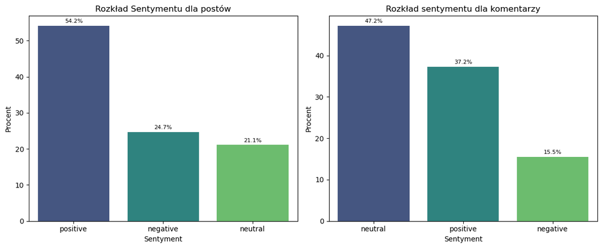

```python
fig, axes = plt.subplots(nrows=1, ncols=2, figsize=(12, 5))

sns.barplot(x=posts_sentiment_distribution.index, y=posts_sentiment_distribution.values, ax=axes[0], palette="viridis")
axes[0].set_title('Rozkład Sentymentu dla postów')
axes[0].set_xlabel('Sentyment')
axes[0].set_ylabel('Procent')

for i, v in enumerate(posts_sentiment_distribution.values):
    axes[0].text(i, v + 0.5, f'{v:.1f}%', ha='center', va='bottom', fontsize=8)

sns.barplot(x=comments_sentiment_distribution.index, y=comments_sentiment_distribution.values, ax=axes[1], palette="viridis")
axes[1].set_title('Rozkład sentymentu dla komentarzy')
axes[1].set_xlabel('Sentyment')
axes[1].set_ylabel('Procent')

for i, v in enumerate(comments_sentiment_distribution.values):
    axes[1].text(i, v + 0.5, f'{v:.1f}%', ha='center', va='bottom', fontsize=8)

plt.tight_layout()
plt.show()
```

## Porównanie rozkładu sentymetu postów w zależności od subreddit

Grupowanie i zliczanie dla Cartalk:

```python
cartalk_sentiment_distribution = ev_posts[ev_posts['subreddit'] == 'Cartalk']['posts_sentiment_label'].value_counts(normalize=True) * 100
```

```python
ev_posts
```

|  | author | score | selftext | subreddit | created_utc | url | num_comments | name | selftext_processed | posts_sentiment_score | posts_sentiment_label |
| --- | --- | --- | --- | --- | --- | --- | --- | --- | --- | --- | --- |
| 23 | [deleted] | 1 | can you drive an automatics kind of like a man... | cars | 2012-01-15 | http://www.reddit.com/r/cars/comments/ohejo/is... | 11 | t3_ohejo | drive automatic kind manual know little thinki... | -0.4460 | negative |
| 24 | [deleted] | 2 | this is my first time driving a manual and i w... | cars | 2012-01-24 | http://www.reddit.com/r/cars/comments/ou2x6/he... | 7 | t3_ou2x6 | first time driving manual wanting ask question... | 0.8126 | positive |
| 25 | iggman5 | 0 | my parents just got a 98 jetta from an auction... | cars | 2012-02-16 | http://www.reddit.com/r/cars/comments/proct/le... | 4 | t3_proct | parent got jetta auction got almost mile minor... | -0.7003 | negative |
| 26 | TurboSalsa | 19 | i guess no one thought to mention this more pr... | cars | 2012-02-22 | http://www.reddit.com/r/cars/comments/q14av/if... | 28 | t3_q14av | guess thought mention prominently owner manual... | 0.2263 | neutral |
| 27 | Jayross | 1 | info we live in vancouver but drive to whistle... | cars | 2012-02-22 | http://www.reddit.com/r/cars/comments/q0gae/my... | 22 | t3_q0gae | info live vancouver drive whistler winter whis... | 0.9217 | positive |
| ... | ... | ... | ... | ... | ... | ... | ... | ... | ... | ... | ... |
| 532 | Mk6GTI- | 2 | i was driving my gti back from work and i har... | Cartalk | 2022-12-14 | https://i.redd.it/g0y7486mht5a1.jpg | 13 | t3_zlf1x3 | driving gti back work hard accelerated around ... | 0.1280 | neutral |
| 533 | CourageousCabbage | 1 | i have a 2008 mazda 3 with an automanual trans... | Cartalk | 2022-12-13 | https://www.reddit.com/r/Cartalk/comments/zl9n... | 2 | t3_zl9nl3 | mazda automanual trans mile bought year ago us... | 0.9609 | positive |
| 534 | edr5619 | 0 | i have a 2008 dodge caliber with 24l engine an... | Cartalk | 2022-12-16 | https://www.reddit.com/r/Cartalk/comments/zn3c... | 1 | t3_zn3cef | dodge caliber engine speed manual transmission... | -0.0772 | neutral |
| 535 | MussleGeeYem | 1 | with hev not phev or bevs being more efficient... | Cartalk | 2022-12-19 | https://www.reddit.com/r/Cartalk/comments/zphd... | 10 | t3_zphdyb | hev phev efficient ice equivalent toyota camry... | 0.8910 | positive |
| 536 | Rude-Sheepherder7885 | 1 | hello rcartalk i got my drivers license almost... | Cartalk | 2022-12-27 | https://www.reddit.com/r/Cartalk/comments/zwof... | 11 | t3_zwofsu | hello rtalk got driver license almost month ag... | 0.6124 | positive |

1720 rows × 11 columns

Grupowanie i zliczanie dla cars:

```python
cars_sentiment_distribution = ev_posts[ev_posts['subreddit'] == 'cars']['posts_sentiment_label'].value_counts(normalize=True) * 100
```

Wykres:

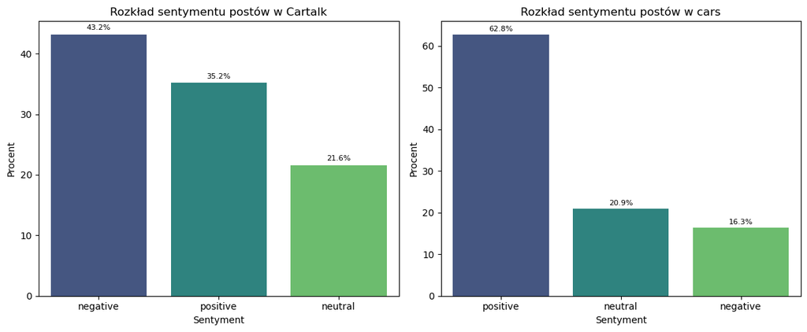

```python
fig, axes = plt.subplots(nrows=1, ncols=2, figsize=(12, 5))

sns.barplot(x=cartalk_sentiment_distribution.index, y=cartalk_sentiment_distribution.values, ax=axes[0], palette="viridis")
axes[0].set_title('Rozkład sentymentu postów w Cartalk')
axes[0].set_xlabel('Sentyment')
axes[0].set_ylabel('Procent')

for i, v in enumerate(cartalk_sentiment_distribution.values):
    axes[0].text(i, v + 0.5, f'{v:.1f}%', ha='center', va='bottom', fontsize=8)

sns.barplot(x=cars_sentiment_distribution.index, y=cars_sentiment_distribution.values, ax=axes[1], palette="viridis")
axes[1].set_title('Rozkład sentymentu postów w cars')
axes[1].set_xlabel('Sentyment')
axes[1].set_ylabel('Procent')

for i, v in enumerate(cars_sentiment_distribution.values):
    axes[1].text(i, v + 0.5, f'{v:.1f}%', ha='center', va='bottom', fontsize=8)

plt.tight_layout()
plt.show()
```

## Porównanie rozkładu sentymetu komentarzy w zależności od subreddit

Grupowanie i zliczanie dla Cartalk:

```python
cartalk_comm_sentiment_distribution = ev_comments[ev_comments['subreddit'] == 'Cartalk']['comm_sentiment_label'].value_counts(normalize=True) * 100
```

Grupowanie i zliczanie dla cars:

```python
cars_comm_sentiment_distribution = ev_comments[ev_comments['subreddit'] == 'cars']['comm_sentiment_label'].value_counts(normalize=True) * 100
```

Wykres:

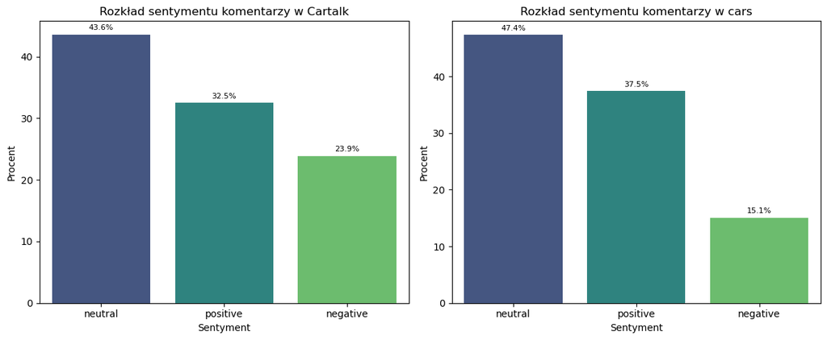

```python
fig, axes = plt.subplots(nrows=1, ncols=2, figsize=(12, 5))

sns.barplot(x=cartalk_comm_sentiment_distribution.index, y=cartalk_comm_sentiment_distribution.values, ax=axes[0], palette="viridis")
axes[0].set_title('Rozkład sentymentu komentarzy w Cartalk')
axes[0].set_xlabel('Sentyment')
axes[0].set_ylabel('Procent')

for i, v in enumerate(cartalk_comm_sentiment_distribution.values):
    axes[0].text(i, v + 0.5, f'{v:.1f}%', ha='center', va='bottom', fontsize=8)

sns.barplot(x=cars_comm_sentiment_distribution.index, y=cars_comm_sentiment_distribution.values, ax=axes[1], palette="viridis")
axes[1].set_title('Rozkład sentymentu komentarzy w cars')
axes[1].set_xlabel('Sentyment')
axes[1].set_ylabel('Procent')

for i, v in enumerate(cars_comm_sentiment_distribution.values):
    axes[1].text(i, v + 0.5, f'{v:.1f}%', ha='center', va='bottom', fontsize=8)

plt.tight_layout()
plt.show()
```

## Ogólny rozkład sentymentu w całym zbiorze

Połączenie zbiorów ev_comments i ev_posts:

```python
combined_data = pd.concat([ev_comments['comm_sentiment_label'], ev_posts['posts_sentiment_label']])
```

Grupowanie i zliczanie dla ogólnego zbioru:

```python
total_sentiment_distribution = combined_data.value_counts(normalize=True) * 100
```

Wykres:

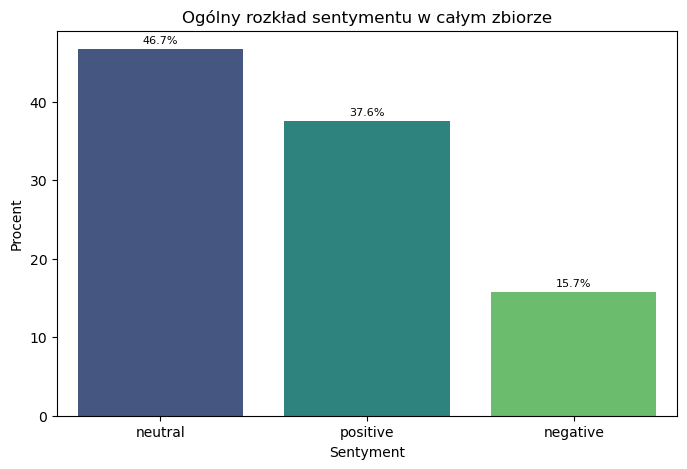

```python
plt.figure(figsize=(8, 5))
sns.barplot(x=total_sentiment_distribution.index, y=total_sentiment_distribution.values, palette="viridis")
plt.title('Ogólny rozkład sentymentu w całym zbiorze')
plt.xlabel('Sentyment')
plt.ylabel('Procent')

for i, v in enumerate(total_sentiment_distribution.values):
    plt.text(i, v + 0.5, f'{v:.1f}%', ha='center', va='bottom', fontsize=8)

plt.show()
```

## Rozkład sentymentu w czasie dla komentarzy i postów

Konwertowanie kolumny 'created_utc' na obiekt datetime:

```python
ev_comments['created_utc'] = pd.to_datetime(ev_comments['created_utc'])
ev_posts['created_utc'] = pd.to_datetime(ev_posts['created_utc'])
```

Utworzenie kolumny 'year' do grupowania co rok:

```python
ev_comments['year'] = ev_comments['created_utc'].dt.to_period("Y")
ev_posts['year'] = ev_posts['created_utc'].dt.to_period("Y")
```

Średni sentyment dla każdego interwału w ev_comments i ev_posts:

```python
avg_sentiment_comments = ev_comments.groupby('year')['comm_sentiment_score'].mean()
avg_sentiment_posts = ev_posts.groupby('year')['posts_sentiment_score'].mean()
```

Wykresy:

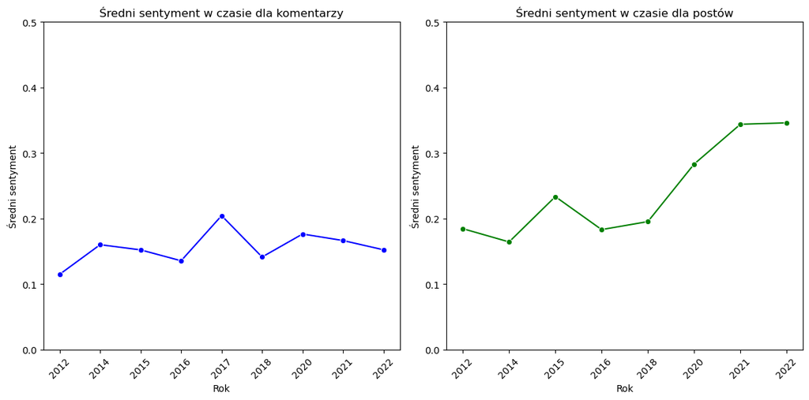

```python
plt.figure(figsize=(12, 6))

# ev_comments
plt.subplot(1, 2, 1)
sns.lineplot(x=avg_sentiment_comments.index.astype(str), y=avg_sentiment_comments.values, marker='o', color='b')
plt.title('Średni sentyment w czasie dla komentarzy')
plt.xlabel('Rok')
plt.ylabel('Średni sentyment')
plt.xticks(rotation=45)
plt.ylim(0, 0.5)

# ev_posts
plt.subplot(1, 2, 2)
sns.lineplot(x=avg_sentiment_posts.index.astype(str), y=avg_sentiment_posts.values, marker='o', color='g')
plt.title('Średni sentyment w czasie dla postów')
plt.xlabel('Rok')
plt.ylabel('Średni sentyment')
plt.xticks(rotation=45)
plt.ylim(0, 0.5)

plt.tight_layout()
plt.show()
```

## Rozkład sentymentu w czasie w całym zbiorze

```python
comments_subset = ev_comments[['created_utc', 'comm_sentiment_score']]
posts_subset = ev_posts[['created_utc', 'posts_sentiment_score']]
```

```python
comments_subset.columns = ['created_utc', 'sentiment_score']
posts_subset.columns = ['created_utc', 'sentiment_score']
```

```python
ev_all = pd.concat([comments_subset, posts_subset], ignore_index=True)
```

Konwertowanie kolumny 'created_utc' na obiekt datetime:

```python
ev_all['created_utc'] = pd.to_datetime(ev_all['created_utc'])
```

Utworzenie kolumny 'year' do grupowania co rok:

```python
ev_all['year'] = ev_all['created_utc'].dt.to_period("Y")
```

Średni sentyment dla każdego interwału czasowego (co rok):

```python
avg_sentiment = ev_all.groupby('year')['sentiment_score'].mean()
```

Wykres:

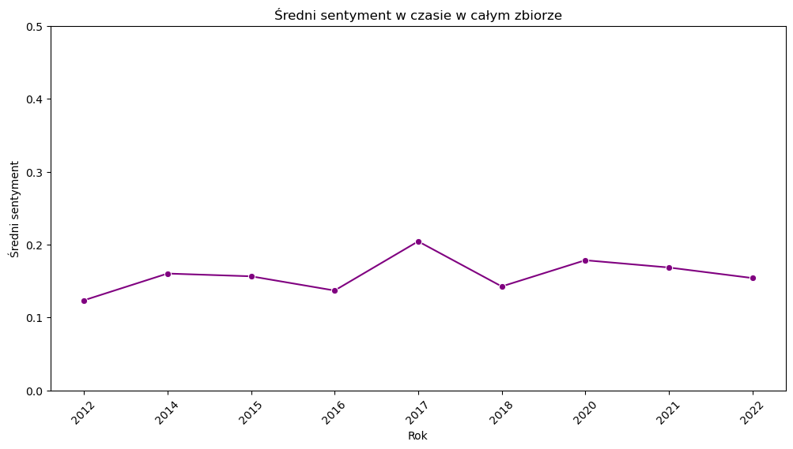

```python
plt.figure(figsize=(12, 6))
sns.lineplot(x=avg_sentiment.index.astype(str), y=avg_sentiment.values, marker='o', color='purple')
plt.title('Średni sentyment w czasie w całym zbiorze')
plt.xlabel('Rok')
plt.ylabel('Średni sentyment')
plt.xticks(rotation=45)
plt.ylim(0, 0.5)
plt.show()
```

## Zależność sentymentu od liczby reakcji pod komentarzami

Wybór kolumn:

```python
subset_comments = ev_comments[['score', 'comm_sentiment_score']]
```

Korelację Pearsona:

```python
correlation_matrix_comments = subset_comments.corr()
```

Macierz korelacji:

```python
print("Macierz korelacji:")
print(correlation_matrix_comments)
```

```
Macierz korelacji:
                         score  comm_sentiment_score
score                 1.000000              0.001539
comm_sentiment_score  0.001539              1.000000
```

## Zależność sentymentu od liczby reakcji pod postem

Wybór kolumn:

```python
subset_posts = ev_posts[['score', 'posts_sentiment_score']]
```

Korelację Pearsona:

```python
correlation_matrix_posts = subset_posts.corr()
```

Macierz korelacji:

```python
print("Macierz korelacji:")
print(correlation_matrix_posts)
```

```
Macierz korelacji:
                          score  posts_sentiment_score
score                  1.000000               0.106558
posts_sentiment_score  0.106558               1.000000
```

## Złączenie obu tabel

Wybranie kolumn z tabeli ev_comments:

```python
ev_comments = ev_comments[['link_id', 'subreddit', 'score', 'created_utc', 'comm_sentiment_score',
                         'comm_sentiment_label','body_processed']]
```

Ustalenie nowych nazw kolumnw tabeli z komentarzami:

```python
new_column_names = {
    'link_id': 'post_id',
    'score': 'comm_score',
    'created_utc': 'comm_date',
    'body_processed': 'comm_text_content'
}
```

Zmiana nazwy kolumn w tabeli z komentarzami:

```python
ev_comments.rename(columns=new_column_names, inplace=True)
```

Wybranie kolumn z tabeli ev_posts:

```python
ev_posts = ev_posts[['name', 'score', 'num_comments','created_utc', 'posts_sentiment_score',
                         'posts_sentiment_label', 'selftext_processed', ]]
```

Ustalenie nowych nazw kolumnw tabeli z postami:

```python
new_column_names_2 = {
    'name': 'post_id',
    'score': 'post_score',
    'num_comments' : 'comments_number',
    'created_utc': 'post_date',
    'selftext_processed': 'post_text_content'
}
```

Zmiana nazwy kolumn w tabeli z komentarzami:

```python
ev_posts.rename(columns=new_column_names_2, inplace=True)
```

Połączenie tabel:

```python
ev = pd.merge(ev_posts, ev_comments, on='post_id')
```

```python
ev
```

|  | post_id | post_score | comments_number | post_date | posts_sentiment_score | posts_sentiment_label | post_text_content | subreddit | comm_score | comm_date | comm_sentiment_score | comm_sentiment_label | comm_text_content |
| --- | --- | --- | --- | --- | --- | --- | --- | --- | --- | --- | --- | --- | --- |
| 0 | t3_ohejo | 1 | 11 | 2012-01-15 | -0.4460 | negative | drive automatic kind manual know little thinki... | cars | 8 | 2012-01-15 | -0.8032 | negative | use le fuel neutral engine already know shut f... |
| 1 | t3_ohejo | 1 | 11 | 2012-01-15 | -0.4460 | negative | drive automatic kind manual know little thinki... | cars | 1 | 2012-01-15 | 0.0000 | neutral | deleted |
| 2 | t3_ohejo | 1 | 11 | 2012-01-15 | -0.4460 | negative | drive automatic kind manual know little thinki... | cars | 4 | 2012-01-15 | 0.0000 | neutral | decelerating gas burned |
| 3 | t3_ohejo | 1 | 11 | 2012-01-15 | -0.4460 | negative | drive automatic kind manual know little thinki... | cars | 6 | 2012-01-15 | -0.3400 | negative | dude want drive manual buy damn manual |
| 4 | t3_ohejo | 1 | 11 | 2012-01-15 | -0.4460 | negative | drive automatic kind manual know little thinki... | cars | 2 | 2012-01-15 | -0.2006 | neutral | manual valve body dropin part basically change... |
| ... | ... | ... | ... | ... | ... | ... | ... | ... | ... | ... | ... | ... | ... |
| 87472 | t3_zwofsu | 1 | 11 | 2022-12-27 | 0.6124 | positive | hello rtalk got driver license almost month ag... | Cartalk | 1 | 2022-12-27 | 0.4404 | positive | make sense thanks comment |
| 87473 | t3_zwofsu | 1 | 11 | 2022-12-27 | 0.6124 | positive | hello rtalk got driver license almost month ag... | Cartalk | 1 | 2022-12-27 | -0.2418 | neutral | worry putting neutral soon possible help absol... |
| 87474 | t3_zwofsu | 1 | 11 | 2022-12-27 | 0.6124 | positive | hello rtalk got driver license almost month ag... | Cartalk | 1 | 2022-12-27 | 0.0000 | neutral | take lesson |
| 87475 | t3_zwofsu | 1 | 11 | 2022-12-27 | 0.6124 | positive | hello rtalk got driver license almost month ag... | Cartalk | 1 | 2022-12-28 | -0.5106 | negative | cruising along mph light turn red let gas push... |
| 87476 | t3_zwofsu | 1 | 11 | 2022-12-27 | 0.6124 | positive | hello rtalk got driver license almost month ag... | Cartalk | 1 | 2022-12-28 | -0.5994 | negative | throw neutral amount gas applied happens resis... |

87477 rows × 13 columns

## Zależność sentymentu komentarzy od sentymentu postów

```python
correlation_matrix = ev[['posts_sentiment_score', 'comm_sentiment_score']].corr()
```

```python
print("Macierz korelacji:")
print(correlation_matrix)
```

```
Macierz korelacji:
                       posts_sentiment_score  comm_sentiment_score
posts_sentiment_score               1.000000              0.091675
comm_sentiment_score                0.091675              1.000000
```

Grupowanie i zliczanie:

```python
subset_positive_posts = ev[ev['posts_sentiment_label'] == 'positive']['comm_sentiment_label'].value_counts(normalize=True) * 100
subset_negative_posts = ev[ev['posts_sentiment_label'] == 'negative']['comm_sentiment_label'].value_counts(normalize=True) * 100
subset_neutral_posts = ev[ev['posts_sentiment_label'] == 'neutral']['comm_sentiment_label'].value_counts(normalize=True) * 100
```

Wykresy:

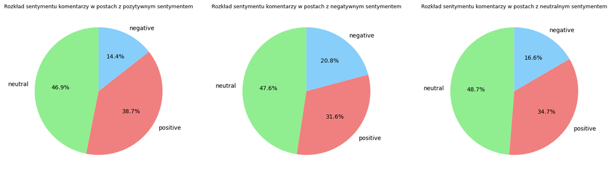

```python
fig, axes = plt.subplots(nrows=1, ncols=3, figsize=(18, 6))
plt.subplots_adjust(wspace=0.3)

# positive
axes[0].pie(subset_positive_posts, labels=subset_positive_posts.index, autopct='%1.1f%%', startangle=90, colors=['lightgreen', 'lightcoral', 'lightskyblue'])
axes[0].set_title('Rozkład sentymentu komentarzy w postach z pozytywnym sentymentem', fontsize=9)

# negative
axes[1].pie(subset_negative_posts, labels=subset_negative_posts.index, autopct='%1.1f%%', startangle=90, colors=['lightgreen', 'lightcoral', 'lightskyblue'])
axes[1].set_title('Rozkład sentymentu komentarzy w postach z negatywnym sentymentem', fontsize=9)

# neutral
axes[2].pie(subset_neutral_posts, labels=subset_neutral_posts.index, autopct='%1.1f%%', startangle=90, colors=['lightgreen', 'lightcoral', 'lightskyblue'])
axes[2].set_title('Rozkład sentymentu komentarzy w postach z neutralnym sentymentem', fontsize=9)

plt.show()
```

# Modelowanie tematyczne

## Chmury słów postów i komentarzy

Łączenie tekstu w jedną długą linię:

```python
text_post = ' '.join(ev_posts['post_text_content'])
```

Inicjalizacja WordCloud z ograniczeniem do 10 słów:

```python
wordcloud = WordCloud(width=800, height=400, background_color='white', max_words=10).generate(text_post)
```

Wyświetlenie chmury słów:

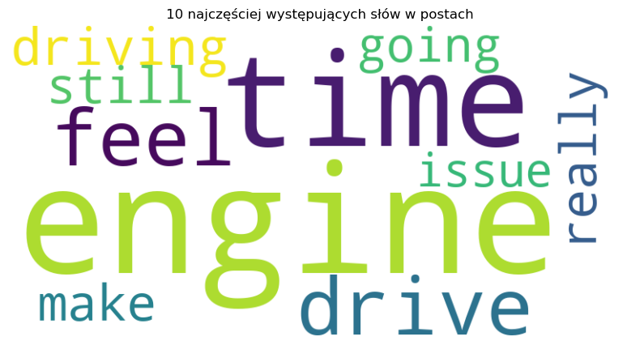

```python
plt.figure(figsize=(10, 5))
plt.imshow(wordcloud, interpolation='bilinear')
plt.axis('off')
plt.title('10 najczęściej występujących słów w postach')
plt.show()
```

Łączenie tekstu w jedną długą linię:

```python
text_comm = ' '.join(ev_comments['comm_text_content'])
```

Inicjalizacja WordCloud z ograniczeniem do 10 słów:

```python
wordcloud = WordCloud(width=800, height=400, background_color='white', max_words=10).generate(text_comm)
```

Wyświetlenie chmury słów:

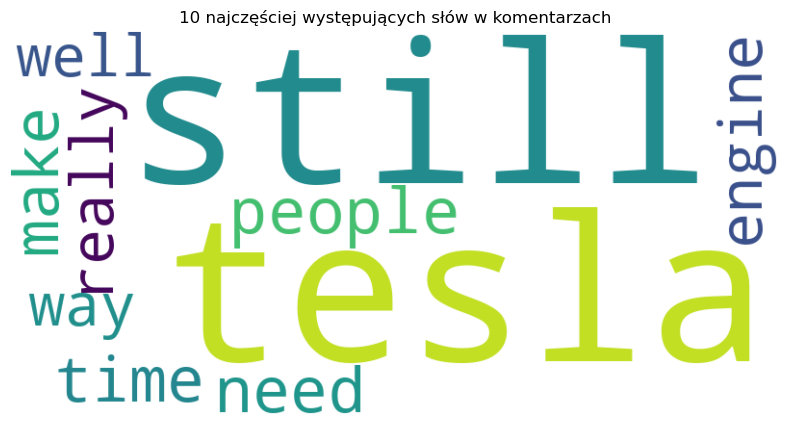

```python
plt.figure(figsize=(10, 5))
plt.imshow(wordcloud, interpolation='bilinear')
plt.axis('off')
plt.title('10 najczęściej występujących słów w komentarzach')
plt.show()
```

## Grupy tematyczne

Przygotowanie danych dla postów:

```python
corpus_posts = ev_posts['post_text_content'].tolist()
```

Wektoryzacja tekstu dla postów:

```python
vectorizer_posts = TfidfVectorizer(max_features=1000, stop_words='english')
X_posts = vectorizer_posts.fit_transform(corpus_posts)
```

Modelowanie tematyczne (LDA) dla postów:

```python
lda_posts = LatentDirichletAllocation(n_components=3, random_state=42)
lda_posts.fit(X_posts)
```

```
LatentDirichletAllocation(n_components=3, random_state=42)
```

Przygotowanie danych dla komentarzy:

```python
corpus_comments = ev_comments['comm_text_content'].tolist()
```

Wektoryzacja tekstu dla komentarzy:

```python
vectorizer_comments = TfidfVectorizer(max_features=1000, stop_words='english')
X_comments = vectorizer_comments.fit_transform(corpus_comments)
```

Modelowanie tematyczne (LDA) dla komentarzy:

```python
lda_comments = LatentDirichletAllocation(n_components=3, random_state=42)
lda_comments.fit(X_comments)
```

```
LatentDirichletAllocation(n_components=3, random_state=42)
```

Wizualizacja tematów dla postów i komentarzy:

```python
feature_names_posts = vectorizer_posts.get_feature_names_out()
feature_names_comments = vectorizer_comments.get_feature_names_out()
```

```python
for topic_idx, topic in enumerate(lda_posts.components_):
    top_words_idx = topic.argsort()[:-7:-1]
    top_words = [feature_names_posts[i] for i in top_words_idx]
    print(f'Temat dla postów {topic_idx + 1}: {", ".join(top_words)}')
```

```
Temat dla postów 1: tesla, electric, vehicle, make, year, people
Temat dla postów 2: hybrid, market, honda, company, industry, electric
Temat dla postów 3: engine, gear, rpm, clutch, start, problem
```

```python
for topic_idx, topic in enumerate(lda_comments.components_):
    top_words_idx = topic.argsort()[:-7:-1]
    top_words = [feature_names_comments[i] for i in top_words_idx]
    print(f'Temat dla komentarzy {topic_idx + 1}: {", ".join(top_words)}')
```

```
Temat dla komentarzy 1: engine, battery, need, mile, power, gas
Temat dla komentarzy 2: look, drive, really, people, driving, know
Temat dla komentarzy 3: deleted, removed, thanks, post, tesla, question
```

## Grupy tematyczne pozytywnych postów

```python
subset_positive_posts = ev_posts[ev_posts['posts_sentiment_label'] == 'positive']
```

```python
corpus_positive_posts = subset_positive_posts['post_text_content'].tolist()
```

```python
vectorizer_positive_posts = TfidfVectorizer(max_features=1000, stop_words='english')
X_positive_posts = vectorizer_positive_posts.fit_transform(corpus_positive_posts)
```

```python
lda_positive_posts = LatentDirichletAllocation(n_components=3, random_state=42)
lda_positive_posts.fit(X_positive_posts)
```

```
LatentDirichletAllocation(n_components=3, random_state=42)
```

```python
feature_positive_posts = vectorizer_positive_posts.get_feature_names_out()
```

```python
for topic_idx, topic in enumerate(lda_positive_posts.components_):
    top_words_idx = topic.argsort()[:-7:-1]
    top_words = [feature_positive_posts[i] for i in top_words_idx]
    print(f'Temat dla postów {topic_idx + 1}: {", ".join(top_words)}')
```

```
Temat dla postów 1: tesla, electric, vehicle, hybrid, year, company
Temat dla postów 2: feel, seat, wheel, steering, sport, interior
Temat dla postów 3: engine, gear, clutch, rpm, transmission, issue
```

### Chmura słów

```python
text_post_positive = ' '.join(subset_positive_posts['post_text_content'])
```

```python
wordcloud = WordCloud(width=800, height=400, background_color='white', max_words=10).generate(text_post_positive)
```

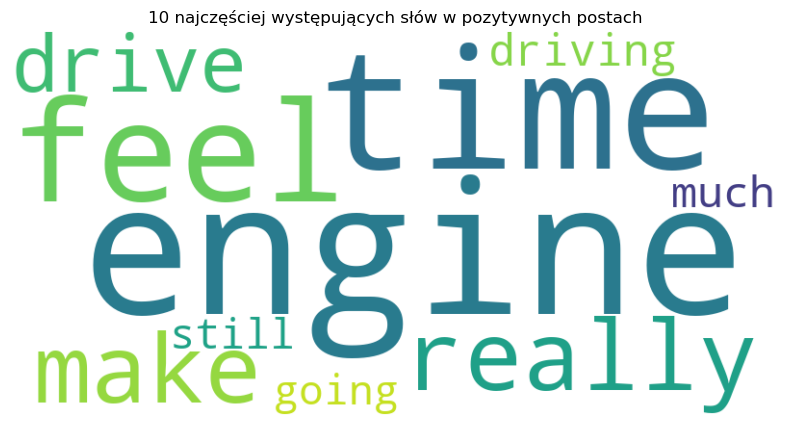

```python
plt.figure(figsize=(10, 5))
plt.imshow(wordcloud, interpolation='bilinear')
plt.axis('off')
plt.title('10 najczęściej występujących słów w pozytywnych postach')
plt.show()
```

## Grupy tematyczne negatywnych postów

```python
subset_negative_posts = ev_posts[ev_posts['posts_sentiment_label'] == 'negative']
```

```python
corpus_negative_posts = subset_negative_posts['post_text_content'].tolist()
```

```python
vectorizer_negative_posts = TfidfVectorizer(max_features=1000, stop_words='english')
X_negative_posts = vectorizer_negative_posts.fit_transform(corpus_negative_posts)
```

```python
lda_negative_posts = LatentDirichletAllocation(n_components=3, random_state=42)
lda_negative_posts.fit(X_negative_posts)
```

```
LatentDirichletAllocation(n_components=3, random_state=42)
```

```python
feature_negative_posts = vectorizer_negative_posts.get_feature_names_out()
```

```python
for topic_idx, topic in enumerate(lda_negative_posts.components_):
    top_words_idx = topic.argsort()[:-7:-1]
    top_words = [feature_negative_posts[i] for i in top_words_idx]
    print(f'Temat dla negatywnych postów {topic_idx + 1}: {", ".join(top_words)}')
```

```
Temat dla negatywnych postów 1: engine, problem, gear, start, rpm, time
Temat dla negatywnych postów 2: imrc, owner, sorry, vroom, modern, dodge
Temat dla negatywnych postów 3: crate, grill, upshifting, returned, mechanical, egr
```

### Chmura słów

```python
text_post_negative = ' '.join(subset_negative_posts['post_text_content'])
```

```python
wordcloud = WordCloud(width=800, height=400, background_color='white', max_words=10).generate(text_post_negative)
```

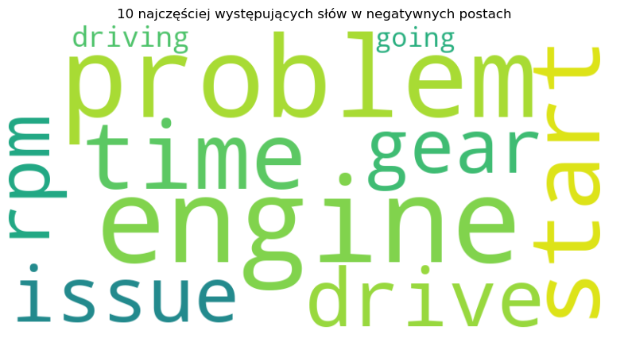

```python
plt.figure(figsize=(10, 5))
plt.imshow(wordcloud, interpolation='bilinear')
plt.axis('off')
plt.title('10 najczęściej występujących słów w negatywnych postach')
plt.show()
```